# Sorbonne_EMariotti IB1248 Cohort_1 - HuSIGHT_FullLength (IgG)

# Sorbonne_EMariotti IB1248 Cohort_1 - HuSIGHT_FullLength (IgG)

#### 19 February, 2026

## Background

**M**olecular **I**ndexing of **P**roteins by **S**elf-**A**ssembly (**MIPSA**) is a novel and proprietary method to construct DNA-barcoded peptide and protein libraries for antibody reactome profiling applications at [Infinity Bio](https://www.infinitybio.com/).

Antibody reactome profiling is the comprehensive analysis of antibody binding (“antibody reactivity”) to a large set of specific antigens (typically > 10,000). Antibodies, also known as immunoglobulins (Ig), are proteins produced by the immune system in response to the presence of foreign substances, such as pathogens, allergens, or even an individual’s own proteins in the case of autoimmune diseases. Antibody profiling can be performed on monoclonal or polyclonal antibodies, including the highly complex mixture of antibodies present in biological fluids like serum or plasma. With MIPSA, antibody reactivities are detected via immunocapture and high-throughput sequencing of antigen-conjugated DNA barcodes. The resulting sequencing data is then processed through Infinity Bio’s bioinformatics analysis pipeline to detect the reactive antibodies.

This report details the reactivities detected towards 16,152 full-length proteins in your samples using Infinity Bio’s HuSIGHT_FullLength MIPSA library.

Samples are processed in 96-well plate format. The 12th column is reserved for Infinity Bio’s internal controls, including 3 positive and negative library-specific serum controls, and 5 PBS (phosphate buffered saline) input “mock IP” or “beads only” controls that are used for fold-over-background downstream calculations. Each sample, including the serum controls and each mock IP control, is individually compared against the complete set of mock IPs associated with the project. This comparison involves the use of the EdgeR software package for data normalization, statistical testing and fold-over-background estimation. For each sample, “hits” are defined as library members with FDR-adjusted p-values < 0.001 to reject the null-hypothesis that the barcode count data is drawn from the background distribution of mock IP read counts. Hits must also have a fold-over-background value of > 3 in comparison to the mock IP controls.

To ensure the quality of each data set, we confirm the following control performance metrics are achieved prior to data release:

- The mapped barcode reads per sample must be at least 10-times the library complexity for at least 90% of the project samples.
- The average number of false positives detected per mock IP must be less than 1.

A report of your project QC metrics and a summary of the detected antibody reactivities for your project are detailed below.

## Project QC

### Positive Control Correlations

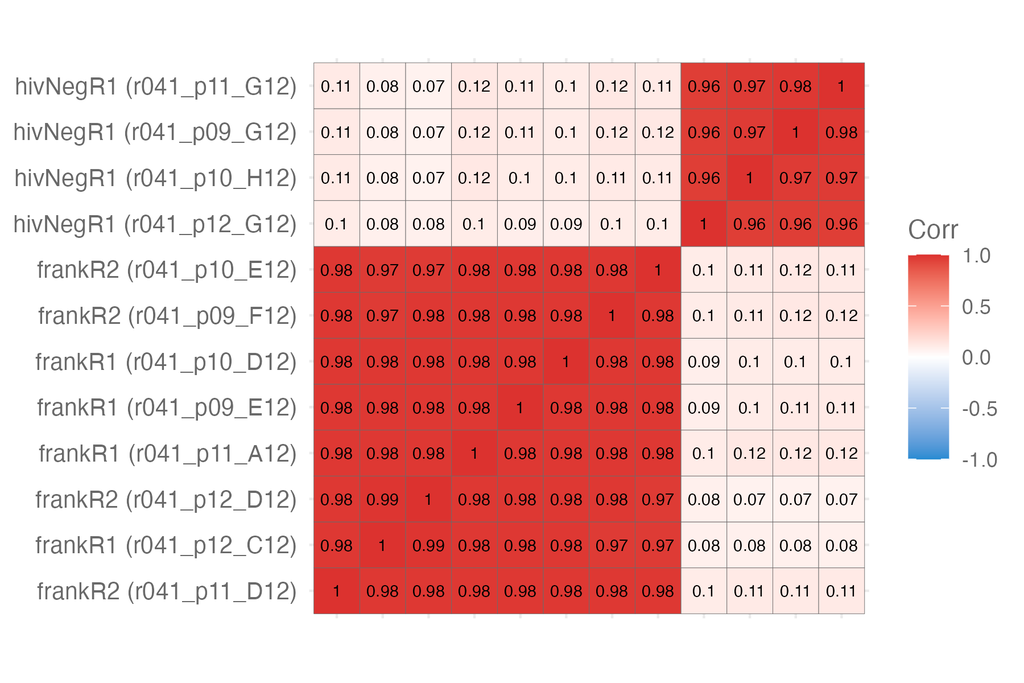

**Figure 1.** Correlation heat map of all serum control samples (Control (+)). Heat map shows Pearson correlation values (-1 to 1) of -log10 FDR-adjusted p-values for each serum control versus every other serum control. Serum control samples are hierarchically clustered by similarity as determined by Pearson correlation. If no serum controls of this type were run for the project, an Infinity Bio logo will appear instead.

## Data Overview

### Reactivities Per Sample

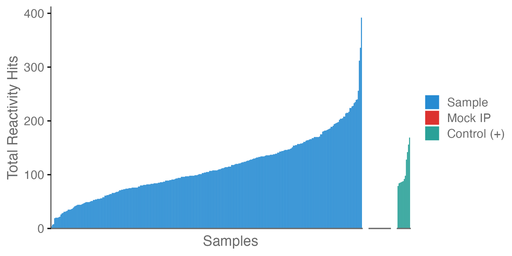

**Figure 2.** Bar plot of number of hits (reactivities) detected per sample. Samples are colored by sample type, including project samples, mock IP background controls and serum control samples (Control (+)). Samples are arranged in ascending order by detected hits and faceted by sample type.

### Navigating Your Data Return

Your data delivery package contains this project-level report, a sub-directory of per-sample reports, and a set of data table outputs. If applicable, your data will be separated into sub-folders by library. Each folder contains this project report, which includes all the definitions and terms relevant to your data. We suggest reviewing the data in the following order:

- **Sorbonne_EMariotti_IB1248_Cohort_1_HuSIGHT_FullLength_IgG_Report.html**: this file, to be opened in an internet browser, is the project-level report which provides QC information, overview reporting and analysis terminology.
- **IB1248_Cohort_1_HuSIGHT_FullLength_IgG_Hits_pvals-Adjusted.csv**: this file provides the EdgeR-derived statistical comparison of each library member’s counts in a sample to that from the mock IP controls, reporting only values for the hits. P-values are FDR corrected (using the Benjamini-Hochberg procedure) and reported as -log10(FDR-adjusted p-values). Non-hit FDR-adjusted p-values are reported as “0”.
- **IB1248_Cohort_1_HuSIGHT_FullLength_IgG_Hits_Fold-Over-Background.csv**: this file provides the EdgeR-derived fold-over-background values of each library member’s counts in a sample to that from the mock IP controls, reporting only values for the hits. Non-hit fold-over-background values are reported as “1”.
- **IB1248_Cohort_1_HuSIGHT_FullLength_IgG_Project-Summary.csv**: this file provides the QC data that are plotted in the project-level report.
- **Supplementary_Files**: this subdirectory contains supplementary data tables for Counts, Fold-Over-Background values, raw p-values, and FDR-corrected p-values. Also contains respective data tables containing filtered out immunoglobulin (Ig) components.
- Individual sample reports are also provided for your convenience, although all this information is also captured in the files mentioned above.

A note about comparing significance (p) values versus fold-over-background values. The relative input abundance of each library member determines the confidence with which reactivities can be detected. Significance values of a given library member can be compared across samples, but significance values of two library members with differing input abundance may not be comparable within a sample. Fold-change values of two library members with differing input abundances are comparable within a sample but might be discordant across samples if the adjusted p-values are near the 0.001 significance threshold. Despite these considerations, the vast majority of significance values are well correlated with fold-over-background values, and so in most cases can these values be used relatively interchangeably.

Please review this document and the related files and then schedule a meeting with our team to answer any questions you might have. In the meantime, please let us know if you have any issues – we are always here to help!

### Methods

For antibody profiling projects, samples are first accessioned into Infinity Bio’s sample tracking system. Samples are then mixed with the HuSIGHT_FullLength MIPSA reagent, which is comprised of full-length human proteins, each with a set of unique DNA barcodes. Antibodies in samples bind to antigens in the library, and antibodies and their bound members are captured via Dyna magnetic beads coated with protein A/G. Barcodes on captured antigen library members are amplified via PCR, and PCR products are submitted for sequencing on an Illumina platform.

Once sequencing results are obtained, FASTQ reads for each individual sample are run through the Infinity Bio bioinformatics pipeline to process and compare each sample in the following ways:

1. Reads for each sample are mapped using [Bowtie2](https://bowtie-bio.sourceforge.net/bowtie2/index.shtml) to a dictionary of mono-associated barcode-feature pairs, which is filtered to contain only sequence-validated library members specific to the HuSIGHT_FullLength library.
2. Each sample is statistically compared to the set of mock IP controls using the R package [edgeR](https://bioconductor.org/packages/release/bioc/html/edgeR.html). Then, detected reactivities (“hits”) are determined for each sample using the criterion that EdgeR-derived adjusted p-value (FDR) to reject the null-hypothesis that the sample read count is drawn from the mock IP background distribution must be < 0.001. Furthermore, the fold-over-background comparison must also be > 3 in comparison to the mock IPs.

### Terminology

- **Depth:** number of mapped barcode sequencing reads produced via Illumina sequencing for each sample in a project.
- **Coverage:** the average number of times each library member of the HuSIGHT_FullLength library is sequenced in a sample. This is calculated as *Number Aligned Reads/Number Library Members* for each sample. We require a coverage of at least 10 in at least 90% of the project samples.
- **Mock IP control:** an assay reaction that includes all input reagents but with PBS in place of sample, which undergoes all steps of the assay process alongside test sample reactions. Designated as “PBS” in data outputs.
- **Hit:** a library member that was determined to be significantly enriched (FDR-adjusted p-value < 0.001, Fold Over Background > 3) in a given sample compared to the set of mock IPs. Also referred to as a reactivity.
- **Fold Over Background:** numerical value calculated via EdgeR indicating the magnitude of difference in counts for a given library member detected in a sample compared to the set of mock IPs associated with the project.
- **Hits Fold Over Background:** fold over background values for each library member that was determined to be a hit in a given sample. All non-hit values are set to 1.
- **Counts:** integer values for the sequencing read counts associated with each member of the HuSIGHT_FullLength library for each sample.

Infinity Bio, Inc. © 2026